# Multiple Linear Correlation

## 1. Assumption are Important

- Different ML models have different assumptions. Understanding a model's assumptions is crucial because if the assumptions are violated, the model results might be misleading/inaccurate.

#### 1.1 Example: Preparing for an Exam

Some students plan their study schedule and make several assumptions that can impact their success.

##### Key Assumptions:

- **Time Needed to Study:** You assume that you will need 10 hours of study time to master the exam material.
- **Coverage of the Material:** You assume that the professor will cover specific topics from the textbook or lecture notes in the exam.
- **Test Format:** You assume that the exam will be multiple-choice, as past exams were, and prepare accordingly.
- **Distractions and Energy Levels:** You assume that you will not face any distractions (like last-minute assignments) or fatigue when studying.

##### Consequences of Incorrect Assumptions:

- If the assumptions hold true, your study plan will likely be effective, and you’ll perform well on the exam. However, the study plan will not be effective and exam score not be good if the assumptions are violated:

  a) you assume 10 hours of study is enough but it turns out you need 20 hours to cover all the material) you might run out of time and not be fully prepared.  
  b) you assume certain topics will be on the test and they are not. c) the professor surprises you with new material, you might struggle during the exam.  
  d) you assume the exam will be multiple-choice and it turns out to be an essay format, your preparation may not match the required skills, and your performance could suffer.  
  e) you encounter unexpected distractions, you may not be able to study as effectively as you planned.

## 2. Linear Regression - Key Assumptions

### 2.1 Residuals

- The residual is the difference between the actual value of the response variable and the predicted value from the regression model.
- Residuals represent the **errors** or the part of the response variable that the model did not explain.
- The residual represents how much the prediction from the model differs from the actual data for each point:The residual is the observed value (actual value of the response variable) minus the predicted value (value predicted by the regression model):

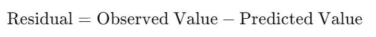

### 2.2 Assumptions

Violations of the assumptions of linearity, homoscedasticity, and multicollinearity in multiple linear regression can affect the reliability, interpretability, and predictive accuracy of the model.

**a) Linearity:** The relationship between the predictors and the response variable is linear.

> **Violation:** If the linearity assumption is violated, the model will not capture the true relationship between variables. This means poor fit, i.e. the model will not fit the data well, leading to a lower R-squared and poor predictive performance. The estimated coefficients will be biased, i.e. "off" or systematically incorrect, which means that their estimated values will be too low or too high with respect to the true coefficients values.  
> **Signs of Violation:** The residual Plot (Plotting residuals vs. fitted values) will show some pattern or curvature instead of a random scatter, indicating a non-linear relationship.

**b) Homoscedasticity:** The residuals (errors) have constant variance at every level of the predictor variables.

> **Violation:** If the residuals have non-constant variance (called heteroscedasticity), The estimates of standard errors may become biased, leading to unreliable p-values and confidence intervals. Statistical tests (e.g., t-tests and F-tests) can be invalid because they rely on the assumption of constant variance in residuals.  
> **Signs of Violation:** The residual plot (Residuals vs. fitted values plot) will show a funnel or fan shape, where the spread of residuals increases or decreases with the fitted values.

**c) Independence:** The residuals are independent of each other. This assumption is important when dealing with time-series data or clustered data.

> **Violation:** The violation leads to underestimating the standard errors of the coefficients which can make predictors appear more statistically significant than they actually are. Also, the p-values calculated for statistical tests may be misleading, affecting the reliability of inferences. **Signs of Violation:**Various tests and plots can be used to detect dependence.

**d) Normality of Residuals:** The residuals should be approximately normally distributed.This assumption is mainly important for statistical inference, i.e. good confidence intervals and hypothesis tests, but has limited impact on the model's ability to estimate coefficients accurately or predict new values. Again, the coefficient estimates and the model's predictive ability are not affected.

> **Violation:** Non-normal residuals can make the standard errors inaccurate, which affects the p-values and confidence intervals calculated for the regression coefficients.  
> **Signs of Violation:** The histogram of the residuals should be normally distributed and resemble a symmetric bell curve.

Skewness (histogram leaning to the left or right) and heavy tails or peakedness (a sharper or flatter curve than expected for normal data) indicate that the residuals are not normally distributed. A Q-Q plot is also a diagnostic too: it compares the quantiles of the residuals to the quantiles of a normal distribution (if the residuals are normally distributed, points should fall along a straight 45-degree line). Other diagnostic test are also available.

**e) No Perfect Multicollinearity:** The predictors should not be perfectly correlated with each other.

> **Violation:** The coefficients of correlated predictors will become highly sensitive to small changes in the data, making them unreliable and unstable. The standard errors of the affected coefficients inflate, leading to wider confidence intervals and potentially rendering significant predictors insignificant. It becomes hard to determine the individual effect of each predictor on the response variable because of the overlap in the information they provide. **Signs of Violation:** The Variance Inflation Factor (VIF) value of the predictors will be above 5 (or 10, in some cases) indicate significant multicollinearity.

Today we will discuss multicollinearity.

## 3. Multicollinearity

- The goal of linear regression is to explain how changes in predictors (independent variables) cause changes in the outcome (dependent variable). Each predictor should be uncorrelated with the other predictors to help explain a unique part of the variation in the outcome variable Y. Linear regression struggles to generate good results with multicollinearity.

#### 3.1 Multicollinearity and What It Causes

- Multicollinearity occurs when two or more numerical predictor variables (independent variables) are highly correlated, meaning they provide redundant information in a regression model.
- With multicollinearity, linear regression cannot clearly determine the individual contribution of each predictor to the dependent variable. The model gets confused about how to assign importance to each variable and the following issues arise:

> **a) Unstable/Large swings in coefficient estimates:** Small changes in the data can lead to wildly different coefficients. The coefficients might become very large (inflated), unstable, depending on slight changes in the data.

**b) Coefficients change signs:** Predictors that should have a positive relationship with the outcome may end up with negative coefficients, and vice versa.  
**c) Imprecise Estimates/Large standard errors:** The standard errors of the coefficient estimates increase, meaning the model has less confidence in those estimates.

### 3.2 How to Detect Multicollinearity: The Variance Inflation Factor (VIF)

- VIF is designed to measure the amount of multicollinearity among numerical variables in a regression model.
- It starts from 1 and has no upper bound.

> `VIF = 1:` No multicollinearity; The predictor is not correlated with the other variables.

`1<VIF< 5:` Moderate multicollinearity. Typically considered acceptable, though you might monitor predictors with VIF closer to 5.  
`VIF > 5:` High multicollinearity. Multicollinearity is considered problematic, and you may want to investigate or address it.  
`VIF > 10:` Very high multicollinearity. This indicates serious multicollinearity problems, and corrective measures should be taken (ex: removing variables, combining variables, or using regularization techniques).

#### Can VIF Values Be as Large as 10,000?

- VIF values can be as large as 10,000 or more in extreme cases of multicollinearity. This occurs when the correlation between two or more predictors is almost perfect (or very close to it). Such high VIF values indicate that one predictor is almost completely predictable by the others, meaning the regression model cannot properly differentiate their individual effects.
- VIF values above 10 are already considered problematic and suggest serious multicollinearity. Values in the range of thousands or tens of thousands mean the model is nearly unable to distinguish between the effects of certain predictors.
- VIF > 5 is usually considered a warning sign, and VIF > 10 indicates serious multicollinearity. Extremely high VIF values (like 10,000 or more) are possible and typically occur when two or more predictors are nearly perfectly correlated, making the model highly unstable.

# 5. Examples With Only Numerical Variables

### 5.1 Example with No Multicollinearity

```python
# Dependencies
import numpy as np
import pandas as pd
import matplotlib.pyplot as plt
import seaborn as sns
import statsmodels.formula.api as smf
from statsmodels.stats.outliers_influence import variance_inflation_factor
```

- Let's generate some synthetic data where the response variable is intentionally a linear combination of the predictors:

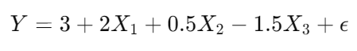

```python
# Fake data
n = 100

X1 = np.random.normal(5,2,n)     # Predictor 1
X2 = np.random.normal(10,5,n)    # Predictor 2
X3 = np.random.normal(20,10,n)   # Predictor 3

Y = 3+2*X1+0.5*X2 -1.5*X3 + np.random.normal(0,2,n)   # response

df = pd.DataFrame( {"X1":X1, "X2":X2, "X3":X3, "Y":Y })
df.head()
```

|  | X1 | X2 | X3 | Y |
| --- | --- | --- | --- | --- |
| 0 | 1.811145 | 14.630888 | 27.569886 | -28.462542 |
| 1 | 3.801250 | 19.547083 | 10.778347 | 6.306540 |
| 2 | 5.010487 | 3.007162 | 28.696059 | -29.928220 |
| 3 | 5.093961 | 12.814846 | 33.556379 | -33.556145 |
| 4 | 4.099869 | 6.746787 | 24.134349 | -24.741650 |

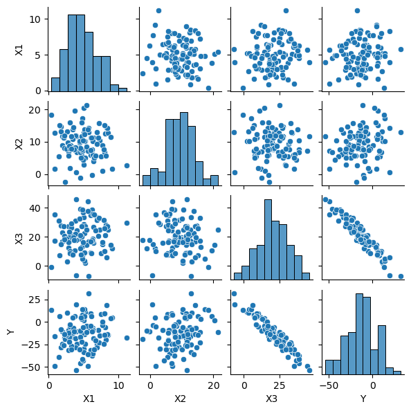

```python
# Visualization
sns.pairplot(df, height=1.5)
plt.show()
```

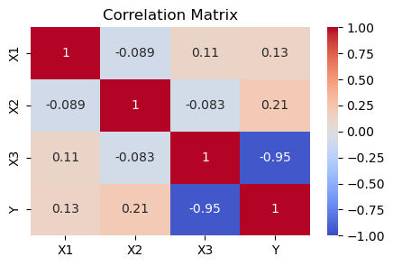

```python
# Correlation Heatmap
plt.figure(figsize= (5,3))
sns.heatmap(df.corr(), annot= True , cmap ="coolwarm", vmin=-1, vmax= 1)
plt.title("Correlation Matrix")
plt.show()
```

```python
# Creating the multiple linear regression model
model_formula = smf.ols( formula= "Y ~ X1 + X2 + X3 " , data= df   )

result = model_formula.fit()

result.summary()
```

OLS Regression Results

| Dep. Variable: | Y | R-squared: | 0.987 |
| --- | --- | --- | --- |
| Model: | OLS | Adj. R-squared: | 0.986 |
| Method: | Least Squares | F-statistic: | 2367. |
| Date: | Thu, 24 Oct 2024 | Prob (F-statistic): | 7.87e-90 |
| Time: | 12:44:50 | Log-Likelihood: | -207.20 |
| No. Observations: | 100 | AIC: | 422.4 |
| Df Residuals: | 96 | BIC: | 432.8 |
| Df Model: | 3 |  |  |
| Covariance Type: | nonrobust |  |  |

|  | coef | std err | t | P>\|t\| | [0.025 | 0.975] |
| --- | --- | --- | --- | --- | --- | --- |
| Intercept | 3.0056 | 0.754 | 3.984 | 0.000 | 1.508 | 4.503 |
| X1 | 2.0018 | 0.094 | 21.398 | 0.000 | 1.816 | 2.188 |
| X2 | 0.5365 | 0.043 | 12.485 | 0.000 | 0.451 | 0.622 |
| X3 | -1.5183 | 0.019 | -81.453 | 0.000 | -1.555 | -1.481 |

| Omnibus: | 0.658 | Durbin-Watson: | 2.143 |
| --- | --- | --- | --- |
| Prob(Omnibus): | 0.720 | Jarque-Bera (JB): | 0.477 |
| Skew: | 0.169 | Prob(JB): | 0.788 |
| Kurtosis: | 3.015 | Cond. No. | 95.8 |

Notes:  
[1] Standard Errors assume that the covariance matrix of the errors is correctly specified.

```python
result.params
```

```
Intercept    3.005561
X1           2.001807
X2           0.536463
X3          -1.518296
dtype: float64
```

### Check Multicollinearity using VIF

```python
vif_data = pd.DataFrame()
X = df[ ["X1", "X2", "X3"]]
vif_data["Feature"] = X.columns

vif_data["VIF"] = [ variance_inflation_factor(X.values ,i) for i in range(X.shape[1] )  ]
vif_data
```

|  | Feature | VIF |
| --- | --- | --- |
| 0 | X1 | 4.168389 |
| 1 | X2 | 3.232419 |
| 2 | X3 | 3.657485 |

### 5.2 Example with Multicollinearity

- We generate synthetic data where the response variable Y is linear correlated with the predictors but multicollinearity is present.

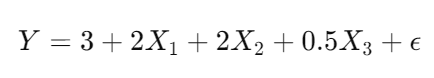

```python
# Create synthetic data with correlated predictors
np.random.seed(42)
n = 100
X1 = np.random.normal(10, 2, n)  # Predictor 1
X2 = 0.9 * X1 + np.random.normal(0, 0.5, n)  # Predictor 2 highly correlated with X1
X3 = np.random.normal(15, 3, n)  # Predictor 3, less correlated

# Create the target variable with a positive relationship with X1 and X2
Y = 3 + 2 * X1 + 2 * X2 + 0.5 * X3 + np.random.normal(0, 2, n)

# Create a DataFrame
df = pd.DataFrame({'X1': X1, 'X2': X2, 'X3': X3, 'Y': Y})
df.head()
```

|  | X1 | X2 | X3 | Y |
| --- | --- | --- | --- | --- |
| 0 | 10.993428 | 9.186400 | 16.073362 | 49.738348 |
| 1 | 9.723471 | 8.540802 | 16.682354 | 46.749361 |
| 2 | 11.295377 | 9.994482 | 18.249154 | 56.198882 |
| 3 | 13.046060 | 11.340315 | 18.161406 | 62.074193 |
| 4 | 9.531693 | 8.497881 | 10.866992 | 44.450841 |

### Correlation Heatmap

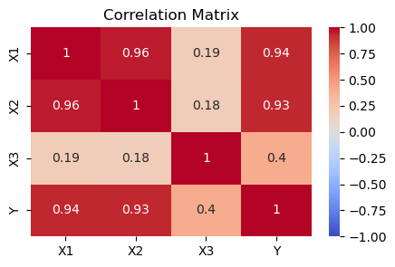

```python
# Correlation Heatmap
plt.figure(figsize= (5,3))
sns.heatmap(df.corr(), annot= True , cmap ="coolwarm", vmin=-1, vmax= 1)
plt.title("Correlation Matrix")
plt.show()
```

```python
# Creating the multiple linear regression model
model_formula = smf.ols( formula= "Y ~ X1 + X2 + X3 " , data= df   )

result = model_formula.fit()
result.summary()
```

OLS Regression Results

| Dep. Variable: | Y | R-squared: | 0.942 |
| --- | --- | --- | --- |
| Model: | OLS | Adj. R-squared: | 0.941 |
| Method: | Least Squares | F-statistic: | 522.7 |
| Date: | Thu, 24 Oct 2024 | Prob (F-statistic): | 2.60e-59 |
| Time: | 12:44:50 | Log-Likelihood: | -196.78 |
| No. Observations: | 100 | AIC: | 401.6 |
| Df Residuals: | 96 | BIC: | 412.0 |
| Df Model: | 3 |  |  |
| Covariance Type: | nonrobust |  |  |

|  | coef | std err | t | P>\|t\| | [0.025 | 0.975] |
| --- | --- | --- | --- | --- | --- | --- |
| Intercept | 4.6793 | 1.184 | 3.951 | 0.000 | 2.329 | 7.030 |
| X1 | 1.9604 | 0.340 | 5.766 | 0.000 | 1.285 | 2.635 |
| X2 | 1.8470 | 0.376 | 4.913 | 0.000 | 1.101 | 2.593 |
| X3 | 0.5179 | 0.056 | 9.312 | 0.000 | 0.408 | 0.628 |

| Omnibus: | 1.353 | Durbin-Watson: | 1.821 |
| --- | --- | --- | --- |
| Prob(Omnibus): | 0.508 | Jarque-Bera (JB): | 1.317 |
| Skew: | 0.169 | Prob(JB): | 0.518 |
| Kurtosis: | 2.551 | Cond. No. | 137. |

Notes:  
[1] Standard Errors assume that the covariance matrix of the errors is correctly specified.

```python
X = df[['X1', 'X2', 'X3']]
X.head()
```

|  | X1 | X2 | X3 |
| --- | --- | --- | --- |
| 0 | 10.993428 | 9.186400 | 16.073362 |
| 1 | 9.723471 | 8.540802 | 16.682354 |
| 2 | 11.295377 | 9.994482 | 18.249154 |
| 3 | 13.046060 | 11.340315 | 18.161406 |
| 4 | 9.531693 | 8.497881 | 10.866992 |

```python
# Check for multicollinearity with Variance Inflation Factor (VIF)
# Check for multicollinearity with Variance Inflation Factor (VIF)
vif_data = pd.DataFrame()
vif_data['Feature'] = X.columns
vif_data['VIF'] = [variance_inflation_factor(X.values, i) for i in range(X.shape[1])]

vif_data
```

|  | Feature | VIF |
| --- | --- | --- |
| 0 | X1 | 364.487363 |
| 1 | X2 | 359.238643 |
| 2 | X3 | 16.476704 |

The VIF values for X1 and X2 are quite high (>10), indicating severe multicollinearity between these two predictors.

### 5.3 Example of Multicollinearity With Sign Flipping

- In this example we create synthetic data where the Y variable is by design a linear combination of the other 3 X variables:

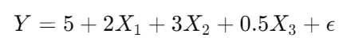

- Some of the predictors will be highly correlated with each other.

```python
# Create an even more extreme example where multicollinearity causes sign flipping
np.random.seed(42)
n = 100

# Generate even more highly correlated predictors
X1 = np.random.normal(10, 2, n)  # Predictor 1
X2 = 0.8 * X1 + np.random.normal(0, 0.01, n)  # Predictor 2 almost perfectly correlated with X1
X3 = np.random.normal(15, 3, n)  # Predictor 3, less correlated

# True relationship: Y = 5 + 2*X1 + 3*X2 + 0.5*X3
Y = 5 + 2 * X1 + 3 * X2 + 0.5 * X3 + np.random.normal(0, 2, n)

# Create a DataFrame
df = pd.DataFrame({'X1': X1, 'X2': X2, 'X3': X3, 'Y': Y})
```

### Correlation Heatmap

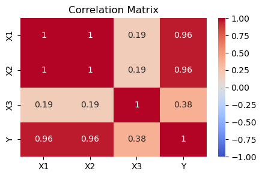

```python
# Correlation Heatmap
plt.figure(figsize= (5,3))
sns.heatmap(df.corr(), annot= True , cmap ="coolwarm", vmin=-1, vmax= 1)
plt.title("Correlation Matrix")
plt.show()
```

### Check Multicollinearity using VIF

```python
# Check for multicollinearity with Variance Inflation Factor (VIF)
X = df[['X1', 'X2', 'X3']]
```

```python
vif_data = pd.DataFrame()
vif_data['Feature'] = X.columns
vif_data['VIF'] = [variance_inflation_factor(X.values, i) for i in range(X.shape[1])]

vif_data
```

|  | Feature | VIF |
| --- | --- | --- |
| 0 | X1 | 707305.221339 |
| 1 | X2 | 707743.949208 |
| 2 | X3 | 16.476704 |

### Creating the Multiple Linear Regression Model

```python
# Creating the multiple linear regression model
model_formula = smf.ols( formula= "Y ~ X1 + X2 + X3 " , data= df   )

result = model_formula.fit()
result.summary()
```

OLS Regression Results

| Dep. Variable: | Y | R-squared: | 0.957 |
| --- | --- | --- | --- |
| Model: | OLS | Adj. R-squared: | 0.955 |
| Method: | Least Squares | F-statistic: | 705.0 |
| Date: | Thu, 24 Oct 2024 | Prob (F-statistic): | 3.13e-65 |
| Time: | 12:44:51 | Log-Likelihood: | -196.78 |
| No. Observations: | 100 | AIC: | 401.6 |
| Df Residuals: | 96 | BIC: | 412.0 |
| Df Model: | 3 |  |  |
| Covariance Type: | nonrobust |  |  |

|  | coef | std err | t | P>\|t\| | [0.025 | 0.975] |
| --- | --- | --- | --- | --- | --- | --- |
| Intercept | 6.6793 | 1.184 | 5.640 | 0.000 | 4.329 | 9.030 |
| X1 | 7.9418 | 15.025 | 0.529 | 0.598 | -21.883 | 37.767 |
| X2 | -4.6489 | 18.798 | -0.247 | 0.805 | -41.962 | 32.664 |
| X3 | 0.5179 | 0.056 | 9.312 | 0.000 | 0.408 | 0.628 |

| Omnibus: | 1.353 | Durbin-Watson: | 1.821 |
| --- | --- | --- | --- |
| Prob(Omnibus): | 0.508 | Jarque-Bera (JB): | 1.317 |
| Skew: | 0.169 | Prob(JB): | 0.518 |
| Kurtosis: | 2.551 | Cond. No. | 2.72e+03 |

Notes:  
[1] Standard Errors assume that the covariance matrix of the errors is correctly specified.  
[2] The condition number is large, 2.72e+03. This might indicate that there are  
strong multicollinearity or other numerical problems.

# 6. Understanding the Model Statistical Summary

- The `summary()` function provides a wealth of information about the model’s performance, statistical significance, and assumptions.

#### Dep. Variable

- It shows the dependent variable (response or target) that you are trying to predict using the linear regression model.

#### Model

- It indicates the type of model, usually OLS (Ordinary Least Squares), for a standard linear regression.

#### Method

- It refers to the estimation method used, which is typically Least Squares for OLS.

#### No. Observations

- The number of observations (data points) used in fitting the model.

#### Df Residuals

- Degrees of freedom of the residuals, which is the number of observations minus the number of estimated parameters (including the intercept).

#### Df Model

- The number of estimated parameters in the model (excluding the intercept), representing the degrees of freedom for the model.

#### Covariance Type

- This describes the type of covariance used to estimate the standard errors. By default, it is usually non-robust, but robust covariance estimates can be specified.

### Main Table Components

#### std err

- The standard error of the coefficient estimates.

#### t

- The t-statistic for each coefficient is calculated by dividing the coefficient by its standard error (coef / std err). It measures whether the coefficient is significantly different from zero.

#### P>|t|

- The p-value corresponding to the t-statistic. A small p-value (typically less than 0.05) indicates that the predictor is statistically significant and has a non-zero effect on the dependent variable.

#### [0.025, 0.975]

- The confidence interval (usually 95%) for each coefficient. It shows the range in which the true coefficient is expected to lie, with a given level of confidence.

### Model Performance Metrics

#### R-squared

- It represents the proportion of variance in the dependent variable that is explained by the independent variables. A value closer to 1 means the model explains a large portion of the variability in the response.

#### Adj. R-squared

- Version of R-squared adjusted for the number of predictors. It penalizes models with more variables that do not contribute much to explaining the variance, providing a more realistic measure of model performance.

#### F-statistic

- tests whether at least one of the predictors is significantly related to the dependent variable. It compares the fit of the model to a baseline (intercept-only) model.

#### Prob (F-statistic)

- The p-value associated with the F-statistic. A low p-value indicates that the overall model is statistically significant (i.e., the independent variables, as a group, explain a significant portion of the variance in the dependent variable).

#### Log-Likelihood

- This is the log of the likelihood function. Higher values indicate a better fit. It’s more useful for comparing multiple models rather than interpreting the value directly.

#### AIC (Akaike Information Criterion)

- A measure of the model's goodness-of-fit that penalizes complexity (i.e., the number of predictors). Lower values indicate a better fit, and it is useful for comparing models.

#### BIC (Bayesian Information Criterion)

- Similar to AIC, but with a larger penalty for the number of parameters. Like AIC, lower values are better and help compare models.

### Diagnostic Tests

#### Omnibus Test

- A test of the skewness and kurtosis of the residuals. If the residuals are normally distributed, the test statistic will be small, and the associated p-value will be large (typically greater than 0.05).

#### Prob(Omnibus)

- The p-value of the Omnibus test. A large p-value suggests the residuals are normally distributed.

#### Jarque-Bera (JB) Test

- Another test for normality of the residuals, focusing on skewness and kurtosis. Like the Omnibus test, a low test statistic and high p-value suggest normality.

#### Prob(JB)

- The p-value for the Jarque-Bera test. A value greater than 0.05 suggests the residuals are normally distributed.

#### Skew

- The skewness of the residuals. A value near 0 suggests symmetry in the distribution of residuals.

#### Kurtosis

- The kurtosis of the residuals. For a normal distribution, this should be close to 3. Higher values indicate more extreme outliers.

#### Durbin-Watson

- This tests for autocorrelation (correlation between residuals). Values close to 2 indicate no autocorrelation, while values significantly below 2 suggest positive autocorrelation, and values significantly above 2 suggest negative autocorrelation.

#### Cond. No. (Condition Number)

- This indicates multicollinearity in the model. A high condition number (typically above 30) suggests that some predictors are highly correlated, which can make the regression unstable.

### General Interpretation Of Statistical Summary

> Significant coefficients are identified by small p-values (typically <0.05) in the P>|t| column.

> The goodness-of-fit of the model is evaluated using the R-squared and Adjusted R-squared values.

> The overall significance of the model is tested with the F-statistic and its p-value.

> Model diagnostics (like Omnibus and Durbin-Watson) help check assumptions like normality and no autocorrelation.